# Exercises for Lecture Block 2

There is one exercise part for each of the two lecture parts:

## Part 1: Deep Feedforward Networks

- Implement a deep neural network for binary classification, working with moon data and cat images.
- Experiment with different network architectures and hyperparameters.

## Part 2: Convolutional Networks

- Implement a small convolutional neural network (CNN) and apply it to the cat data.
- Adapt your CNN to also work with more than two classes, and apply it to the MNIST data set.

```python
import datetime
import matplotlib.pyplot as plt
import numpy as np
import struct
import tensorflow as tf
```

```python
from sklearn.datasets import make_moons
from sklearn.model_selection import train_test_split
from sklearn.metrics import accuracy_score

SEED = 1234
```

# Part 1: Deep Feedforward Networks

- Complete the following class for defining a flexible deep binary classification model using TensorFlow.
- The argument `layersizes` will be a list of integers specifying the number of units per layer, starting with the input layer (dimensionality of the data) and potentially several hidden layers. The output layer will not be part of this list. E.g., `[ 128, 64 ]` means the data is 128-dimensional and there shall be one hidden layer with 64 neurons.
- All hidden layers shall use the ReLU activation function `tf.nn.relu`. The output layer should use the sigmoid function `tf.sigmoid`.
- Use `tf.nn.sigmoid_cross_entropy_with_logits` as loss.
- `optimizer` will be one of these strings: `gd` for gradient descent, `mom` for Momentum, `adam` for Adam, `rms` for RMSProp. Use the respective optimzers from https://www.tensorflow.org/api_guides/python/train#Optimizers to minimize the cost.
- `learning_rate` will be a float specifiying the learning rate.
- It is recommended to keep the convention of having the input data as *row* vectors stacked together vertically, when you hand the data to the model via placeholders. This way you can stick to the formulas we have seen several times:

[figure not shown]

$$\large \begin{array}{rl} A^{[0]} & = X\\ z^{[1]} & = A^{[0]} W^{[1]} + b^{[1]}\\ A^{[1]} & = r(z^{[1]})\\ \\ z^{[\ell]} & = A^{[\ell-1]} W^{[\ell]} + b^{[\ell]}\\ A^{[\ell]} & = g^{[\ell]}(z^{[\ell]})\\ \\ \hat{Y} & = A^{[L]} \end{array} $$

```python
class DeepBinaryClassificationModel():
    def __init__(self, layersizes, optimizer, learning_rate, momentum=0.01):
        tf.set_random_seed(SEED)
        inputDimensions = layersizes[0]

        # set up placeholders for the input
        self.inputs = tf.placeholder(tf.float32, shape=[None, inputDimensions], name='inputs')
        self.outputs = tf.placeholder(tf.float32, shape=[None, 1], name='outputs')

        # set up the hidden layers (ReLU) in a loop
        self.W = [None] * len(layersizes)
        self.b = [None] * len(layersizes)
        self.z = [None] * len(layersizes)
        self.a = [None] * len(layersizes)

        self.a[0] = self.inputs


        for layerIdx, neuronCount in enumerate(layersizes):
            if layerIdx == 0:
                continue;

            previousLayerIdx = layerIdx - 1

            self.W[layerIdx] = tf.Variable(tf.random_normal([layersizes[previousLayerIdx], neuronCount]))
            self.b[layerIdx] = tf.Variable(tf.random_normal([1, neuronCount]))
            self.z[layerIdx] = tf.add(tf.matmul(self.a[previousLayerIdx], self.W[layerIdx]), self.b[layerIdx])
            self.a[layerIdx] = tf.nn.relu(self.z[layerIdx])


        # set up the final layer (sigmoid)
        self.WOut = tf.Variable(tf.random_normal([layersizes[-1], 1]))
        self.bOut = tf.Variable(tf.random_normal([1, 1]))
        self.zOut = tf.add(tf.matmul(self.a[-1], self.WOut), self.bOut)
        self.yhat = tf.sigmoid(self.zOut, name='yhat')

        # set up the cost and the training step
        self.cost = tf.reduce_mean(tf.nn.sigmoid_cross_entropy_with_logits(labels=self.outputs, logits=self.zOut), name='cost')
        optimizers = {
            "gd": tf.train.GradientDescentOptimizer(learning_rate).minimize(self.cost),
            "mom": tf.train.MomentumOptimizer(learning_rate, momentum).minimize(self.cost),
            "adam": tf.train.AdamOptimizer(learning_rate).minimize(self.cost),
            "rms": tf.train.RMSPropOptimizer(learning_rate).minimize(self.cost)
        }
        self.train_step = optimizers[optimizer]

        self.accuracy = tf.contrib.metrics.accuracy(
            tf.cast(self.outputs, tf.bool),
            tf.cast(tf.round(self.yhat), tf.bool),
            name='accuracy_computation')

        tf.summary.scalar('Accuracy', self.accuracy)
        tf.summary.scalar('Cost', self.cost)

        self.merged = tf.summary.merge_all()
```

# Deep Learning for Moons

- Generate data using `X, y = make_moons(n_samples=1000, noise=0.15, random_state=SEED)` as we already did in the last exercise
- Make a stratified 80%-20% train-test split
- Use your new deep model to solve this problem. Start with a simple setup (no hidden layers) and few epochs, to debug your model.
- When you got it working, add Tensorboard visualization of:
  - the computation graph
  - the training and test cost
  - the training and test accuracy
- Try different numbers of layers and layer sizes, as well as learning rates and numbers of epochs. Try out the different optimizers. Find a configuration that works well in terms of test set accuracy.
- At the end you should submit this jupyter notebook plus screenshots showing the tensorboard stuff.

```python
# generate data
X, y = make_moons(n_samples=1000, noise=0.15, random_state=SEED)
# train/test split
X_train, X_test, y_train, y_test = train_test_split(X, y, test_size=0.2, random_state=SEED, stratify=y)
```

```python
def test_model(layersizes, optimizer, learning_rate, epochs):
    tf.reset_default_graph() # Otherwise an InvalidArgument exception occurs when calculating the summary.

    # instantiate your model
    model = DeepBinaryClassificationModel(layersizes, optimizer, learning_rate)
    init = tf.global_variables_initializer()

    # start a TensorFlow session, repeatedly train your network in an epoch loop
    with tf.Session() as sess:
        sess.run(init)

        layerConfiguration = '-'.join(map(str, layersizes))
        configuration = f'{layerConfiguration}_{optimizer}_{learning_rate}_{epochs}'
        nowstr = datetime.datetime.now().strftime('%Y-%m-%d_%H.%M.%S')
        trainwriter = tf.summary.FileWriter(f'summaries_hidden_layer_more/{nowstr}_train_{configuration}', sess.graph)
        testwriter = tf.summary.FileWriter(f'summaries_hidden_layer_more/{nowstr}_test_{configuration}')

        for epoch in range(1, epochs + 1):
            fd_train = { model.inputs: X_train, model.outputs: y_train.reshape(-1, 1) }
            fd_test = { model.inputs: X_test, model.outputs: y_test.reshape(-1, 1) }

            _, cost = sess.run([model.train_step, model.cost], feed_dict=fd_train)

            train_probas = sess.run(model.yhat, feed_dict=fd_train)
            test_probas = sess.run(model.yhat, feed_dict=fd_test)
            if epoch % 500 == 0:
                train_acc, summary = sess.run([ model.accuracy, model.merged ], feed_dict=fd_train)
                trainwriter.add_summary(summary, epoch)
                trainwriter.flush()

                # the same using the test data
                test_acc, summary = sess.run([ model.accuracy, model.merged ], feed_dict=fd_test)
                testwriter.add_summary(summary, epoch)
                testwriter.flush()


                print('Epoch %4d of %d Train accuracy: %f Test accuracy: %f' % (epoch, epochs, train_acc, test_acc))

# set these values appropriately
layersizes =[[2, 4, 2], [2, 8, 4, 2]]
optimizers = ['gd','mom', 'adam', 'rms']
learning_rates = [0.1, 0.01, 0.2]
epochs = [3000, 4000]

for layersize in layersizes:
    for optimizer in optimizers:
        for learning_rate in learning_rates:
            for epoch in epochs:
                test_model(layersize, optimizer, learning_rate, epoch)
```

```
Epoch  500 of 3000 Train accuracy: 0.960000 Test accuracy: 0.985000
Epoch 1000 of 3000 Train accuracy: 0.990000 Test accuracy: 1.000000
Epoch 1500 of 3000 Train accuracy: 0.991250 Test accuracy: 0.995000
Epoch 2000 of 3000 Train accuracy: 0.993750 Test accuracy: 0.995000
Epoch 2500 of 3000 Train accuracy: 0.993750 Test accuracy: 0.995000
Epoch 3000 of 3000 Train accuracy: 0.993750 Test accuracy: 0.995000
Epoch  500 of 4000 Train accuracy: 0.975000 Test accuracy: 0.995000
Epoch 1000 of 4000 Train accuracy: 0.988750 Test accuracy: 0.995000
Epoch 1500 of 4000 Train accuracy: 0.992500 Test accuracy: 0.995000
Epoch 2000 of 4000 Train accuracy: 0.992500 Test accuracy: 0.995000
Epoch 2500 of 4000 Train accuracy: 0.992500 Test accuracy: 0.995000
Epoch 3000 of 4000 Train accuracy: 0.992500 Test accuracy: 0.995000
Epoch 3500 of 4000 Train accuracy: 0.993750 Test accuracy: 0.995000
Epoch 4000 of 4000 Train accuracy: 0.993750 Test accuracy: 0.995000
Epoch  500 of 3000 Train accuracy: 0.655000 Test accuracy: 0.620000
Epoch 1000 of 3000 Train accuracy: 0.851250 Test accuracy: 0.860000
Epoch 1500 of 3000 Train accuracy: 0.863750 Test accuracy: 0.880000
Epoch 2000 of 3000 Train accuracy: 0.865000 Test accuracy: 0.880000
Epoch 2500 of 3000 Train accuracy: 0.866250 Test accuracy: 0.880000
Epoch 3000 of 3000 Train accuracy: 0.867500 Test accuracy: 0.880000
Epoch  500 of 4000 Train accuracy: 0.496250 Test accuracy: 0.495000
Epoch 1000 of 4000 Train accuracy: 0.497500 Test accuracy: 0.505000
Epoch 1500 of 4000 Train accuracy: 0.497500 Test accuracy: 0.500000
Epoch 2000 of 4000 Train accuracy: 0.500000 Test accuracy: 0.500000
Epoch 2500 of 4000 Train accuracy: 0.500000 Test accuracy: 0.500000
Epoch 3000 of 4000 Train accuracy: 0.500000 Test accuracy: 0.500000
Epoch 3500 of 4000 Train accuracy: 0.500000 Test accuracy: 0.500000
Epoch 4000 of 4000 Train accuracy: 0.500000 Test accuracy: 0.500000
Epoch  500 of 3000 Train accuracy: 0.982500 Test accuracy: 0.995000
Epoch 1000 of 3000 Train accuracy: 0.988750 Test accuracy: 0.995000
Epoch 1500 of 3000 Train accuracy: 0.988750 Test accuracy: 0.995000
Epoch 2000 of 3000 Train accuracy: 0.988750 Test accuracy: 0.995000
Epoch 2500 of 3000 Train accuracy: 0.988750 Test accuracy: 0.995000
Epoch 3000 of 3000 Train accuracy: 0.988750 Test accuracy: 0.995000
Epoch  500 of 4000 Train accuracy: 0.878750 Test accuracy: 0.910000
Epoch 1000 of 4000 Train accuracy: 0.982500 Test accuracy: 1.000000
Epoch 1500 of 4000 Train accuracy: 0.990000 Test accuracy: 0.995000
Epoch 2000 of 4000 Train accuracy: 0.990000 Test accuracy: 0.995000
Epoch 2500 of 4000 Train accuracy: 0.991250 Test accuracy: 0.995000
Epoch 3000 of 4000 Train accuracy: 0.991250 Test accuracy: 0.995000
```

[output cut: 281 more lines]

```
Epoch 4000 of 4000 Train accuracy: 0.995000 Test accuracy: 0.990000
Epoch  500 of 3000 Train accuracy: 0.995000 Test accuracy: 0.995000
Epoch 1000 of 3000 Train accuracy: 0.991250 Test accuracy: 1.000000
Epoch 1500 of 3000 Train accuracy: 0.993750 Test accuracy: 0.995000
Epoch 2000 of 3000 Train accuracy: 0.996250 Test accuracy: 0.995000
Epoch 2500 of 3000 Train accuracy: 0.993750 Test accuracy: 0.995000
Epoch 3000 of 3000 Train accuracy: 0.983750 Test accuracy: 0.985000
Epoch  500 of 4000 Train accuracy: 0.985000 Test accuracy: 1.000000
Epoch 1000 of 4000 Train accuracy: 0.993750 Test accuracy: 0.995000
Epoch 1500 of 4000 Train accuracy: 0.987500 Test accuracy: 0.995000
Epoch 2000 of 4000 Train accuracy: 0.993750 Test accuracy: 0.995000
Epoch 2500 of 4000 Train accuracy: 0.987500 Test accuracy: 0.990000
Epoch 3000 of 4000 Train accuracy: 0.988750 Test accuracy: 0.995000
Epoch 3500 of 4000 Train accuracy: 0.982500 Test accuracy: 0.990000
Epoch 4000 of 4000 Train accuracy: 0.988750 Test accuracy: 0.995000
```

Some models are at almost 99% accuracy after only 500 iterations when using the higher learning rate of 0.2 especially with the RMS and Adam optimizers. Reducing the learning rate lead to some models never converging, RMS and Adam still performed better than Gradient Descent and the Momentum optimizer.

[figure not shown]

The graph view shows each variable on its own in one long line which is not really useful. It also does not load anymore when I tried to take some screenshots, maybe it can not handle 48 models at once.

# Deep Learning for Cats

Next repeat the same on the following dataset:

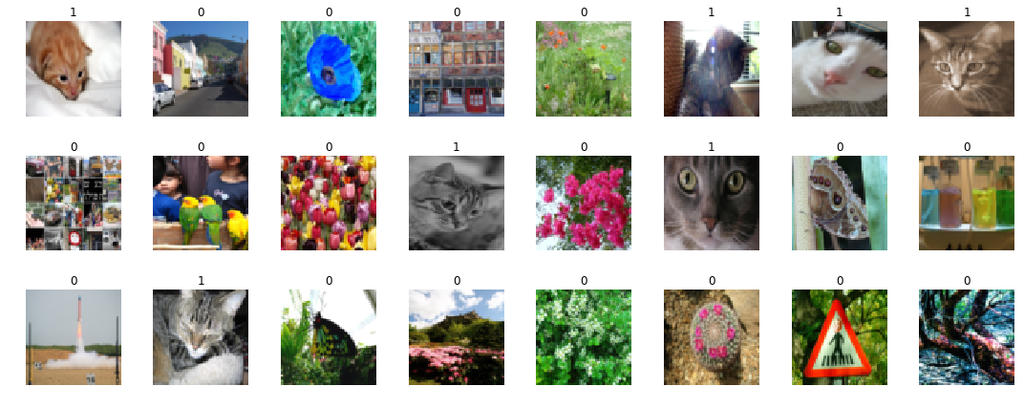

```python
cats_train_x_orig = np.load('data/cats_train_x.npy')
cats_train_y_orig = np.load('data/cats_train_y.npy')
cats_test_x_orig = np.load('data/cats_test_x.npy')
cats_test_y_orig = np.load('data/cats_test_y.npy')

cols = 8
rows = 3
f, axes = plt.subplots(rows, cols, figsize=(15, rows*2))
for i in range(rows):
    for j in range(cols):
        axes[i,j].imshow(cats_train_x_orig[i*cols+j])
        axes[i,j].set_title(cats_train_y_orig[i*cols+j])
        axes[i,j].set_axis_off()
f.tight_layout()
```

Let's inspect this data:

```python
print(cats_train_x_orig.shape)
print(cats_train_y_orig.shape)
print(cats_test_x_orig.shape)
print(cats_test_y_orig.shape)
print(np.unique(cats_train_y_orig, return_counts=True))
print(np.unique(cats_test_y_orig, return_counts=True))
```

```
(207, 64, 64, 3)
(207,)
(52, 64, 64, 3)
(52,)
(array([0, 1], dtype=int64), array([123,  84], dtype=int64))
(array([0, 1], dtype=int64), array([31, 21], dtype=int64))
```

The training set contains 207 examples, each of them of size 64 x 64 x 3, i.e., 64x64 pixels of RGB data. The test set looks the same, but has only 52 examples. In the training set, 84 examples are labeled as cats and 123 as non-cats. In the test data, 21 are labeled as cats and 31 as non-cats.

We need to reshape this data into (high-dimensional) row vectors, as discussed in the first lecture, and we'll re-scale them to the interval [0,1]. It can be done like this:

```python
cats_train_x = cats_train_x_orig.reshape(cats_train_x_orig.shape[0], -1) / 255
cats_test_x = cats_test_x_orig.reshape(cats_test_x_orig.shape[0], -1) / 255
cats_train_y = cats_train_y_orig.reshape(-1, 1).astype(float)
cats_test_y = cats_test_y_orig.reshape(-1, 1).astype(float)
print(cats_train_x.shape)
print(cats_test_x.shape)
print(cats_train_y.shape)
print(cats_test_y.shape)
```

```
(207, 12288)
(52, 12288)
(207, 1)
(52, 1)
```

- Now use your flexible deep model from above to solve this problem. Again, try different numbers of layers and layer sizes, as well as learning rates and numbers of epochs. Try out the different optimizers. Find a configuration that works well in terms of test set accuracy.
- Again, submit screenshots of the tensorboard stuff also for this cat task.

**The best submitted solution in terms of test set accuracy on the cat data will win a prize!**

```python
def test_cat_model(layersizes, optimizer, learning_rate, epochs):
    tf.reset_default_graph() # Otherwise an InvalidArgument exception occurs when calculating the summary.

    # instantiate your model
    model = DeepBinaryClassificationModel(layersizes, optimizer, learning_rate)
    init = tf.global_variables_initializer()

    # start a TensorFlow session, repeatedly train your network in an epoch loop
    with tf.Session() as sess:
        sess.run(init)

        layerConfiguration = '-'.join(map(str, layersizes))
        configuration = f'{layerConfiguration}_{optimizer}_{learning_rate}_{epochs}'
        nowstr = datetime.datetime.now().strftime('%Y-%m-%d_%H.%M.%S')
        trainwriter = tf.summary.FileWriter(f'summaries_cat_model/{nowstr}_train_{configuration}', sess.graph)
        testwriter = tf.summary.FileWriter(f'summaries_cat_model/{nowstr}_test_{configuration}')

        for epoch in range(1, epochs + 1):
            fd_train = { model.inputs: cats_train_x, model.outputs: cats_train_y }
            fd_test = { model.inputs: cats_test_x, model.outputs: cats_test_y }

            sess.run(model.train_step, feed_dict=fd_train)

            if epoch % 10 == 0:
                train_acc, summary = sess.run([ model.accuracy, model.merged ], feed_dict=fd_train)
                trainwriter.add_summary(summary, epoch)
                trainwriter.flush()

                # the same using the test data
                test_acc, summary = sess.run([ model.accuracy, model.merged ], feed_dict=fd_test)
                testwriter.add_summary(summary, epoch)
                testwriter.flush()


                print('Epoch %4d of %d Train accuracy: %f Test accuracy: %f' % (epoch, epochs, train_acc, test_acc))


test_cat_model([12288, 3072, 192, 32, 2], 'adam', 0.1, 200000)
```

```
Epoch   10 of 200000 Train accuracy: 0.594203 Test accuracy: 0.596154
Epoch   20 of 200000 Train accuracy: 0.594203 Test accuracy: 0.596154
```

[output not shown]

For some reason my model does not converge on anything usefull and I could not figure out what is currently wrong. The cost function converges until a certain value is reached and then stays there. yhat also stays always the same. I gave up after 4 hours of no progress. My sad attempts are in the `summaries_cat_model` directory.

# Part 2: Convolutional Networks

## Part 2.1: Implement a CNN classification model

Implement the deep CNN model which we discussed in class, as shown in the picture below. Note, however, that the picture shows the situation of processing **one single image at a time**. We want to process images in batches, so all the sizes need an additional number in the front. Let's assume a batch size of 100 for the description in the following, and an image size of 32 x 32 pixels and 3 color channels. In your implementation, all of these will be parameters passed to the consturctor of the model.

1. The inputs shall be of shape 100 x 32 x 32 x 3 (batch_size x image_height x image_width x image_channels).
2. The outputs shall be of shape 100 x 1 (batch_size x 1).
3. Use `tf.placeholder`s for the inputs and outputs, and add an additional placeholder `num` for the number of inputs (we want to be able to pass in fewer than batch_size examples).
4. Next we want a convolutional layer with filter size 5 x 5, a stride of 1, no padding (`padding='VALID'`), and 6 filters. You can define the whole filter bank of six filters at once, as a `tf.Variable` of shape `5, 5, 3, 6`.
5. Use the function [tf.nn.conv2d](https://www.tensorflow.org/api_docs/python/tf/nn/conv2d) for the convolution.
6. Add biases, and use the [tf.nn.relu](https://www.tensorflow.org/api_docs/python/tf/nn/relu) function as activation.
7. Next, apply max pooling using the [tf.nn.max_pool](https://www.tensorflow.org/api_docs/python/tf/nn/max_pool) function, with `ksize=[ 1, 2, 2, 1 ]` and `strides=[ 1, 2, 2, 1 ]` and `padding='VALID'` (= no padding).
8. Add another convolutional layer with filter size 5 x 5, a stride of 1, no padding, and 16 filters.
9. Add biases and again use the ReLU function.
10. Reshape the result to `(batchsize, -1)` -- in our example, 100 x 400 -- using the function [tf.reshape](https://www.tensorflow.org/api_docs/python/tf/reshape).
11. Add a fully connected layer of size 120, using the ReLU function, just like we did in non-convolutional networks.
12. Add another fully connected layer of size 84, using the ReLU function.
13. For the loss, use `tf.reduce_sum(tf.nn.sigmoid_cross_entropy_with_logits(...))` (we used `tf.reduce_mean` in the past) and divide the result by `tf.cast(self.num, tf.float32)`. This way, we can compute the average loss correctly even when we don't have a complete batch.
14. Use the [Adam optimizer](https://www.tensorflow.org/api_docs/python/tf/train/AdamOptimizer)
15. Use [tf.sigmoid](https://www.tensorflow.org/api_docs/python/tf/math/sigmoid) as final activation
16. Don't compute the accuracy for the current batch, but instead compute the number of correct predictions (we will compute the accuracy across all batches outside):

    ```
    equal = tf.equal(
     tf.cast(self.output[0:self.num], tf.bool),
     tf.cast(tf.round(self.prediction[0:self.num]), tf.bool),
    )
    self.num_correct = tf.reduce_sum(tf.cast(equal, tf.float32), name='accuracy_computation')
    ```

17. You don't need to add any summaries, we will also do that outside.

Here's the image describing the network from class:

[figure not shown]

The fact that the text above uses 32x32 images and the cat pictures where 64x64 was a bit confusing to me. The Cat pictures also use a single output value and not 10 like in the picture above.

```python
# use these constants for the definition of the respective layers
CONV1_f = 5
CONV1_n = 6
CONV2_f = 5
CONV2_n = 16
FULL1_n = 120
FULL2_n = 84

class CNN:
    def __init__(self, num_classes, image_height, image_width, image_channels, batch_size, learning_rate):

        # Parameters
        self.batch_size = batch_size
        self.learning_rate = learning_rate
        self.image_height = image_height
        self.image_width = image_width
        self.image_channels = image_channels

        # Inputs
        self.num = tf.placeholder(tf.int32)
        self.input = tf.placeholder(tf.float32, shape=[batch_size, image_height, image_width, image_channels])
        self.output = tf.placeholder(tf.float32, shape=[None, 1])

        # Weights & biases
        self.Wconv1 = tf.Variable(tf.random_normal([CONV1_f, CONV1_f, image_channels, CONV1_n]))
        self.bconv1 = tf.Variable(tf.random_normal([CONV1_n]))

        self.Wconv2 = tf.Variable(tf.random_normal([CONV2_f, CONV2_f, CONV1_n, CONV2_n]))
        self.bconv2 = tf.Variable(tf.random_normal([CONV2_n]))

        self.Wfull1 = tf.Variable(tf.random_normal([13*13*16, FULL1_n]))
        self.bfull1 = tf.Variable(tf.random_normal([FULL1_n]))

        self.Wfull2 = tf.Variable(tf.random_normal([FULL1_n, FULL2_n]))
        self.bfull2 = tf.Variable(tf.random_normal([FULL2_n]))

        self.WOut = tf.Variable(tf.random_normal([FULL2_n, 1]))
        self.bOut = tf.Variable(tf.random_normal([1]))

        # Setup
        self.__setup_layers(self.input)
        self.__setup_training()
        self.__setup_model_evaluation()

        self.init = tf.global_variables_initializer()

    def __conv2d(self, input, W, b, strides=1):
        input = tf.nn.conv2d(input, W, strides=[1, strides, strides, 1], padding='VALID')
        input = tf.nn.bias_add(input, b)
        return tf.nn.relu(input)

    def __maxpool2d(self, input, k=2):
        return tf.nn.max_pool(input, ksize=[1, k, k, 1], strides=[1, k, k, 1], padding='VALID')

    def __full_conv(self, input, W, b):
        input = tf.add(tf.matmul(input, W), b)
        input = tf.nn.relu(input);
        return input

    def __setup_layers(self, input):
        #input = tf.reshape(input, shape=[-1, self.image_height, self.image_width, self.image_channels])

        # First Layer
        conv1 = self.__conv2d(input, self.Wconv1, self.bconv1)
        conv1 = self.__maxpool2d(conv1)

        # Second Layer
        conv2 = self.__conv2d(conv1, self.Wconv2, self.bconv2)
        conv2 = self.__maxpool2d(conv2)

        # Reshape
        reshaped = tf.reshape(conv2, [self.batch_size, -1])

        # Full Layers
        full1 = self.__full_conv(reshaped, self.Wfull1, self.bfull1)
        full2 = self.__full_conv(full1, self.Wfull2, self.bfull2)

        # Out
        self.logits = tf.add(tf.matmul(full2, self.WOut), self.bOut)
        self.prediction = tf.nn.sigmoid(self.logits);

    def __setup_training(self):
        self.loss = tf.reduce_mean(tf.nn.sigmoid_cross_entropy_with_logits(logits=self.logits, labels=self.output))
        self.optimizer = tf.train.AdamOptimizer(learning_rate=self.learning_rate)
        self.train_step = self.optimizer.minimize(self.loss)

    def __setup_model_evaluation(self):
        equal = tf.equal(
            tf.cast(self.output[0:self.num], tf.bool),
            tf.cast(tf.round(self.prediction[0:self.num]), tf.bool),
        )
        self.num_correct = tf.reduce_sum(tf.cast(equal, tf.float32), name='accuracy_computation')
```

### Cat Data Set

Apply your CNN to the cat data set we have used before. You should expect to achieve an accuracy of 1.0 on the training set, but only about 0.6 on the test set, because the training data set is very small (207 images). To save you time, the code for the training loop etc. is provided below.

```python
cats_train_x = np.load('data/cats_train_x.npy') / 255
cats_train_y = np.load('data/cats_train_y.npy').reshape(-1, 1)
cats_test_x = np.load('data/cats_test_x.npy') / 255
cats_test_y = np.load('data/cats_test_y.npy').reshape(-1, 1)
```

```python
cats_train_y.shape
```

```
(207, 1)
```

```python
tf.reset_default_graph()
cats_image_height = cats_train_x.shape[1]
cats_image_width = cats_train_x.shape[2]
cats_image_channels = cats_train_x.shape[3]
cats_batch_size = cats_train_x.shape[0] # use all images at once, no real batching
cats_epochs = 100
cats_learning_rate = 0.01
model = CNN(2, cats_image_width, cats_image_width, cats_image_channels, cats_batch_size, cats_learning_rate)

with tf.Session() as sess:
    sess.run(model.init)
    nowstr = datetime.datetime.now().strftime('%Y-%m-%d_%H.%M.%S')
    train_writer = tf.summary.FileWriter('cat_cnn_summaries/%s_train' % nowstr, sess.graph)
    test_writer = tf.summary.FileWriter('cat_cnn_summaries/%s_test' % nowstr)

    train_fd = {
        model.num: cats_batch_size,
        model.input: cats_train_x,
        model.output: cats_train_y,
    }
    # the test data does not fill a complete batch, fill the rest up with zeros
    missing = cats_batch_size - cats_test_x.shape[0]
    padded_test_x = np.pad(cats_test_x, [ (0, missing), (0, 0), (0, 0), (0, 0) ], 'constant')
    padded_test_y = np.pad(cats_test_y, [ (0, missing), (0, 0) ], 'constant')
    test_fd = {
        model.num: cats_test_x.shape[0],
        model.input: padded_test_x,
        model.output: padded_test_y,
    }

    for epoch in range(1, cats_epochs+1):

        _ = sess.run(model.train_step, feed_dict=train_fd)

        if epoch % 5 == 0:
            train_loss, train_correct = sess.run(
                [ model.loss, model.num_correct ],
                feed_dict=train_fd
            )
            train_acc = train_correct / cats_batch_size
            summary = tf.Summary()
            summary.value.add(tag='loss', simple_value=train_loss)
            train_writer.add_summary(summary, epoch)
            summary = tf.Summary()
            summary.value.add(tag='accuracy', simple_value=train_acc)
            train_writer.add_summary(summary, epoch)
            train_writer.flush()

            test_loss, test_correct = sess.run(
                [ model.loss, model.num_correct ],
                feed_dict=test_fd
            )
            test_acc = test_correct / cats_test_x.shape[0]
            summary = tf.Summary()
            summary.value.add(tag='loss', simple_value=test_loss)
            test_writer.add_summary(summary, epoch)
            summary = tf.Summary()
            summary.value.add(tag='accuracy', simple_value=test_acc)
            test_writer.add_summary(summary, epoch)
            test_writer.flush()

            print('Epoch %4d of %d Train loss: %f Train accuracy: %f Test accuracy: %f' %
                  (epoch, cats_epochs, train_loss, train_acc, test_acc))
```

```
Epoch    5 of 100 Train loss: 14472.036133 Train accuracy: 0.502415 Test accuracy: 0.461538
Epoch   10 of 100 Train loss: 4315.873535 Train accuracy: 0.681159 Test accuracy: 0.596154
Epoch   15 of 100 Train loss: 1911.050537 Train accuracy: 0.681159 Test accuracy: 0.634615
Epoch   20 of 100 Train loss: 1012.559753 Train accuracy: 0.830918 Test accuracy: 0.653846
Epoch   25 of 100 Train loss: 684.598145 Train accuracy: 0.797101 Test accuracy: 0.576923
Epoch   30 of 100 Train loss: 229.292755 Train accuracy: 0.888889 Test accuracy: 0.653846
Epoch   35 of 100 Train loss: 116.885948 Train accuracy: 0.937198 Test accuracy: 0.576923
Epoch   40 of 100 Train loss: 62.416580 Train accuracy: 0.946860 Test accuracy: 0.576923
Epoch   45 of 100 Train loss: 9.055349 Train accuracy: 0.985507 Test accuracy: 0.596154
Epoch   50 of 100 Train loss: 0.081976 Train accuracy: 0.995169 Test accuracy: 0.615385
Epoch   55 of 100 Train loss: 0.000000 Train accuracy: 1.000000 Test accuracy: 0.615385
Epoch   60 of 100 Train loss: 0.324860 Train accuracy: 0.995169 Test accuracy: 0.615385
Epoch   65 of 100 Train loss: 0.000074 Train accuracy: 1.000000 Test accuracy: 0.634615
Epoch   70 of 100 Train loss: 0.000000 Train accuracy: 1.000000 Test accuracy: 0.653846
Epoch   75 of 100 Train loss: 0.401275 Train accuracy: 0.995169 Test accuracy: 0.653846
Epoch   80 of 100 Train loss: 0.000000 Train accuracy: 1.000000 Test accuracy: 0.653846
Epoch   85 of 100 Train loss: 0.000000 Train accuracy: 1.000000 Test accuracy: 0.653846
Epoch   90 of 100 Train loss: 0.000000 Train accuracy: 1.000000 Test accuracy: 0.653846
Epoch   95 of 100 Train loss: 0.000000 Train accuracy: 1.000000 Test accuracy: 0.653846
Epoch  100 of 100 Train loss: 0.000000 Train accuracy: 1.000000 Test accuracy: 0.653846
```

## Part 2.2: Adapt Model for More Than Two Classes

Adapt your CNN model above, so it can also do classification for more than two classes. Add if-else blocks to your model where appropriate. For more than two classes you will need the following:

1. Your output placeholder will be of shape batch_size x num_classes (one-hot encoding).
2. The dimensionality of your output layer should not be 1 but num_classes (affects the size of the last weight matrix and the last biases).
3. For the loss, use [tf.nn.softmax_cross_entropy_with_logits_v2](https://www.tensorflow.org/api_docs/python/tf/nn/softmax_cross_entropy_with_logits_v2) instead of [tf.nn.sigmoid_cross_entropy_with_logits](https://www.tensorflow.org/api_docs/python/tf/nn/sigmoid_cross_entropy_with_logits)
4. For the predictions, use [tf.nn.softmax](https://www.tensorflow.org/api_docs/python/tf/nn/softmax).
5. Compute the number of correct predictions as

   ```
   equal = tf.equal(
    tf.argmax(self.prediction[0:self.num], 1),
    tf.argmax(self.output[0:self.num], 1),
   )
   self.num_correct = tf.reduce_sum(tf.cast(equal, tf.float32), name='accuracy_computation')
   ```

```python
# use these constants for the definition of the respective layers
CONV1_f = 5
CONV1_n = 6
CONV2_f = 5
CONV2_n = 16
FULL1_n = 120
FULL2_n = 84

class CNN2:
    def __init__(self, num_classes, image_height, image_width, image_channels, batch_size, learning_rate):

        # Parameters
        self.batch_size = batch_size
        self.learning_rate = learning_rate
        self.image_height = image_height
        self.image_width = image_width
        self.image_channels = image_channels

        # Inputs
        self.num = tf.placeholder(tf.int32)
        self.input = tf.placeholder(tf.float32, shape=[batch_size, image_height, image_width, image_channels])
        self.output = tf.placeholder(tf.float32, shape=[None, num_classes])

        # Weights & biases
        self.Wconv1 = tf.Variable(tf.random_normal([CONV1_f, CONV1_f, image_channels, CONV1_n]))
        self.bconv1 = tf.Variable(tf.random_normal([CONV1_n]))

        self.Wconv2 = tf.Variable(tf.random_normal([CONV2_f, CONV2_f, CONV1_n, CONV2_n]))
        self.bconv2 = tf.Variable(tf.random_normal([CONV2_n]))

        self.Wfull1 = tf.Variable(tf.random_normal([4*4*16, FULL1_n]))
        self.bfull1 = tf.Variable(tf.random_normal([FULL1_n]))

        self.Wfull2 = tf.Variable(tf.random_normal([FULL1_n, FULL2_n]))
        self.bfull2 = tf.Variable(tf.random_normal([FULL2_n]))

        self.WOut = tf.Variable(tf.random_normal([FULL2_n, num_classes]))
        self.bOut = tf.Variable(tf.random_normal([num_classes]))

        # Setup
        self.__setup_layers(self.input)
        self.__setup_training()
        self.__setup_model_evaluation()

        self.init = tf.global_variables_initializer()

    def __conv2d(self, input, W, b, strides=1):
        input = tf.nn.conv2d(input, W, strides=[1, strides, strides, 1], padding='VALID')
        input = tf.nn.bias_add(input, b)
        return tf.nn.relu(input)

    def __maxpool2d(self, input, k=2):
        return tf.nn.max_pool(input, ksize=[1, k, k, 1], strides=[1, k, k, 1], padding='VALID')

    def __full_conv(self, input, W, b):
        input = tf.add(tf.matmul(input, W), b)
        input = tf.nn.relu(input);
        return input

    def __setup_layers(self, input):
        #input = tf.reshape(input, shape=[-1, self.image_height, self.image_width, self.image_channels])

        # First Layer
        conv1 = self.__conv2d(input, self.Wconv1, self.bconv1)
        conv1 = self.__maxpool2d(conv1)

        # Second Layer
        conv2 = self.__conv2d(conv1, self.Wconv2, self.bconv2)
        conv2 = self.__maxpool2d(conv2)

        # Reshape
        reshaped = tf.reshape(conv2, [self.batch_size, -1])

        # Full Layers
        full1 = self.__full_conv(reshaped, self.Wfull1, self.bfull1)
        full2 = self.__full_conv(full1, self.Wfull2, self.bfull2)

        # Out
        self.logits = tf.add(tf.matmul(full2, self.WOut), self.bOut)
        self.prediction = tf.nn.softmax(self.logits);

    def __setup_training(self):
        self.loss = tf.reduce_mean(tf.nn.softmax_cross_entropy_with_logits(logits=self.logits, labels=self.output))
        self.optimizer = tf.train.AdamOptimizer(learning_rate=self.learning_rate)
        self.train_step = self.optimizer.minimize(self.loss)

    def __setup_model_evaluation(self):
        equal = tf.equal(
            tf.argmax(self.prediction[0:self.num], 1),
            tf.argmax(self.output[0:self.num], 1),
        )
        self.num_correct = tf.reduce_sum(tf.cast(equal, tf.float32), name='accuracy_computation')
```

## MNIST Data Set

Next, apply the CNN to a bigger data set, the MNIST data set of hand written digits (http://yann.lecun.com/exdb/mnist/). Again, the code is provided for you, so you just need to make your CNN class work with this code, no changes below required. But make sure you look at it, it contains code for mini-batch training.

```python
class MNISTData:

    def read_idx(self, filename):
        with open(filename, 'rb') as f:
            zero, data_type, dims = struct.unpack('>HBB', f.read(4))
            shape = tuple(struct.unpack('>I', f.read(4))[0] for d in range(dims))
            return np.frombuffer(f.read(), dtype=np.uint8).reshape(shape)

    def plot_some(self, cols, rows):
        f, axes = plt.subplots(rows, cols, figsize=(15, rows*2))
        for i in range(rows):
            for j in range(cols):
                axes[i,j].imshow(self.train_images[i*cols+j,:,:,0], cmap='Greys')
                axes[i,j].set_title(self.train_labels_dense[i*cols+j])
                axes[i,j].set_axis_off()
        f.tight_layout()

    def dense_to_onehot(self, dense, num_classes):
        n = dense.shape[0]
        result = np.zeros((n, num_classes), dtype=np.int8)
        index_offset = np.arange(n) * num_classes
        result.flat[index_offset + dense.ravel()] = 1
        return result

    def training_batches(self, batch_size):
        shuf = np.arange(len(self.train_images))
        np.random.shuffle(shuf)
        images = self.train_images[shuf]
        labels = self.train_labels[shuf]
        offset = 0
        while offset < len(images):
            yield (images[offset:offset+batch_size], labels[offset:offset+batch_size])
            offset += batch_size

    def test_batches(self, batch_size):
        shuf = np.arange(len(self.test_images))
        np.random.shuffle(shuf)
        images = self.test_images[shuf]
        labels = self.test_labels[shuf]
        offset = 0
        while offset < len(images):
            yield (images[offset:offset+batch_size], labels[offset:offset+batch_size])
            offset += batch_size

    def __init__(self):
        self.train_images = self.read_idx('data/train-images-idx3-ubyte') / 255
        self.test_images = self.read_idx('data/t10k-images-idx3-ubyte') / 255

        # reshape to explicit 1-channel images
        shape = list(self.train_images.shape) + [ 1 ]
        self.train_images = self.train_images.reshape(shape)
        shape = list(self.test_images.shape) + [ 1 ]
        self.test_images = self.test_images.reshape(shape)

        self.train_labels_dense = self.read_idx('data/train-labels-idx1-ubyte')
        self.test_labels_dense = self.read_idx('data/t10k-labels-idx1-ubyte')

        # one-hot encoding
        self.num_classes = len(np.unique(self.train_labels_dense))
        self.train_labels = self.dense_to_onehot(self.train_labels_dense, self.num_classes)
        self.test_labels = self.dense_to_onehot(self.test_labels_dense, self.num_classes)
```

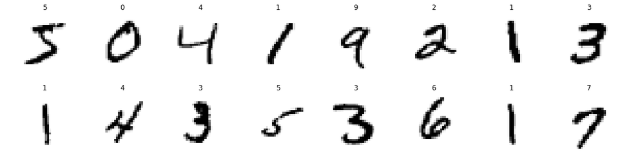

```python
mnist = MNISTData()
mnist.plot_some(8, 2)
```

```python
print(mnist.train_images.shape)
print(mnist.test_images.shape)
print(mnist.train_labels.shape)
print(mnist.test_labels.shape)
print(mnist.train_labels.sum(axis=0))
print(mnist.test_labels.sum(axis=0))
```

```
(60000, 28, 28, 1)
(10000, 28, 28, 1)
(60000, 10)
(10000, 10)
[5923 6742 5958 6131 5842 5421 5918 6265 5851 5949]
[ 980 1135 1032 1010  982  892  958 1028  974 1009]
```

```python
tf.reset_default_graph()
epochs = 100
learning_rate = 0.001
batch_size = 1000
mnist = MNISTData()
mnist_model = CNN2(
    mnist.num_classes,
    mnist.train_images.shape[1],
    mnist.train_images.shape[2],
    mnist.train_images.shape[3],
    batch_size,
    learning_rate,
)

with tf.Session() as sess:
    sess.run(mnist_model.init)
    nowstr = datetime.datetime.now().strftime('%Y-%m-%d_%H.%M.%S')
    train_writer = tf.summary.FileWriter('mnist_cnn_summaries/%s_train' % nowstr, sess.graph)
    test_writer = tf.summary.FileWriter('mnist_cnn_summaries/%s_test' % nowstr)

    for epoch in range(1, epochs+1):
        # Training: loop over training data in batches
        for i, batch in enumerate(mnist.training_batches(batch_size)):
            batch_inputs, batch_outputs = batch
            missing = batch_size - len(batch_inputs)
            padded_train_x = np.pad(batch_inputs, [ (0, missing), (0, 0), (0, 0), (0, 0) ], 'constant')
            padded_train_y = np.pad(batch_outputs, [ (0, missing), (0, 0) ], 'constant')
            train_fd = {
                mnist_model.num: len(batch_inputs),
                mnist_model.input: padded_train_x,
                mnist_model.output: padded_train_y,
            }
            _ = sess.run(mnist_model.train_step, feed_dict=train_fd)

        if epoch % 5 == 0:
            # for the two blocks below, we should really write a function

            # Evaluation: loop over training data in batches
            train_total_loss = 0
            train_total_correct = 0
            train_total_num = 0
            for i, batch in enumerate(mnist.training_batches(batch_size)):
                batch_inputs, batch_outputs = batch
                missing = batch_size - len(batch_inputs)
                padded_train_x = np.pad(batch_inputs, [ (0, missing), (0, 0), (0, 0), (0, 0) ], 'constant')
                padded_train_y = np.pad(batch_outputs, [ (0, missing), (0, 0) ], 'constant')
                train_fd = {
                    mnist_model.num: len(batch_inputs),
                    mnist_model.input: padded_train_x,
                    mnist_model.output: padded_train_y,
                }
                batch_loss, batch_correct = sess.run([ mnist_model.loss, mnist_model.num_correct ], feed_dict=train_fd)
                train_total_loss += batch_loss
                train_total_correct += batch_correct
                train_total_num += len(batch_inputs)
            train_acc = train_total_correct / train_total_num
            train_avg_loss = train_total_loss / train_total_num
            summary = tf.Summary()
            summary.value.add(tag='loss', simple_value=train_total_loss)
            train_writer.add_summary(summary, epoch)
            summary = tf.Summary()
            summary.value.add(tag='accuracy', simple_value=train_acc)
            train_writer.add_summary(summary, epoch)
            train_writer.flush()

            # Evaluation: loop over test data in batches
            test_total_loss = 0
            test_total_correct = 0
            test_total_num = 0
            for i, batch in enumerate(mnist.test_batches(batch_size)):
                batch_inputs, batch_outputs = batch
                missing = batch_size - len(batch_inputs)
                padded_test_x = np.pad(batch_inputs, [ (0, missing), (0, 0), (0, 0), (0, 0) ], 'constant')
                padded_test_y = np.pad(batch_outputs, [ (0, missing), (0, 0) ], 'constant')
                test_fd = {
                    mnist_model.num: len(batch_inputs),
                    mnist_model.input: padded_test_x,
                    mnist_model.output: padded_test_y,
                }
                batch_loss, batch_correct = sess.run([ mnist_model.loss, mnist_model.num_correct ], feed_dict=test_fd)
                test_total_loss += batch_loss
                test_total_correct += batch_correct
                test_total_num += len(batch_inputs)
            test_acc = test_total_correct / test_total_num
            test_avg_loss = test_total_loss / test_total_num
            summary = tf.Summary()
            summary.value.add(tag='loss', simple_value=test_total_loss)
            test_writer.add_summary(summary, epoch)
            summary = tf.Summary()
            summary.value.add(tag='accuracy', simple_value=test_acc)
            test_writer.add_summary(summary, epoch)
            test_writer.flush()

            print('Epoch %4d of %d Train loss: %f Train accuracy: %f Test accuracy: %f' %
                  (epoch, epochs, train_avg_loss, train_acc, test_acc))
```

```
Epoch    5 of 100 Train loss: 1.091473 Train accuracy: 0.733400 Test accuracy: 0.738500
Epoch   10 of 100 Train loss: 0.536906 Train accuracy: 0.831667 Test accuracy: 0.835100
Epoch   15 of 100 Train loss: 0.342744 Train accuracy: 0.878150 Test accuracy: 0.878800
Epoch   20 of 100 Train loss: 0.250308 Train accuracy: 0.901383 Test accuracy: 0.900400
Epoch   25 of 100 Train loss: 0.195110 Train accuracy: 0.915450 Test accuracy: 0.914400
Epoch   30 of 100 Train loss: 0.156132 Train accuracy: 0.926183 Test accuracy: 0.925100
Epoch   35 of 100 Train loss: 0.127853 Train accuracy: 0.935700 Test accuracy: 0.931400
Epoch   40 of 100 Train loss: 0.106356 Train accuracy: 0.942233 Test accuracy: 0.935000
Epoch   45 of 100 Train loss: 0.089143 Train accuracy: 0.948850 Test accuracy: 0.937800
Epoch   50 of 100 Train loss: 0.076518 Train accuracy: 0.952617 Test accuracy: 0.941900
Epoch   55 of 100 Train loss: 0.065139 Train accuracy: 0.957700 Test accuracy: 0.944800
Epoch   60 of 100 Train loss: 0.055990 Train accuracy: 0.960383 Test accuracy: 0.946800
Epoch   65 of 100 Train loss: 0.047869 Train accuracy: 0.964433 Test accuracy: 0.949800
Epoch   70 of 100 Train loss: 0.041040 Train accuracy: 0.967683 Test accuracy: 0.951600
Epoch   75 of 100 Train loss: 0.035426 Train accuracy: 0.969583 Test accuracy: 0.952500
Epoch   80 of 100 Train loss: 0.030685 Train accuracy: 0.971567 Test accuracy: 0.954400
Epoch   85 of 100 Train loss: 0.026446 Train accuracy: 0.973067 Test accuracy: 0.955900
Epoch   90 of 100 Train loss: 0.022983 Train accuracy: 0.975650 Test accuracy: 0.957800
Epoch   95 of 100 Train loss: 0.019771 Train accuracy: 0.977517 Test accuracy: 0.958000
Epoch  100 of 100 Train loss: 0.017862 Train accuracy: 0.977267 Test accuracy: 0.958200
```